| [*Home*](https://antonio-catalano.github.io/) | [*About*](https://antonio-catalano.github.io/about.html) | [*Archive*](https://antonio-catalano.github.io/Archive.html) |  |
| --- | --- | --- | --- |

# In this simulation i will show that expected value of the ensemble wealth increases with time but wealth over time is doomed.

**We will start with 100 people, each having 100 \$ at the start of simulation. Each person, at every step, can win 0.5 $\times$ wealth, or lose 0.4 $\times$ wealth.**

```python
import numpy as np, pandas as pd, matplotlib.pyplot as plt
plt.style.use('seaborn-whitegrid')
```

The process starts in the way showed below.  
The Average of the ensemble wealth at the beginning of the process is 100.

```python
starting_process = pd.DataFrame({i:100 for i in np.arange(100)}, index = ['step 0'])
starting_process['Sample Average'] = starting_process.mean(axis=1)
starting_process
```

|  | 0 | 1 | 2 | 3 | 4 | 5 | 6 | 7 | 8 | 9 | ... | 91 | 92 | 93 | 94 | 95 | 96 | 97 | 98 | 99 | Sample Average |
| --- | --- | --- | --- | --- | --- | --- | --- | --- | --- | --- | --- | --- | --- | --- | --- | --- | --- | --- | --- | --- | --- |
| step 0 | 100 | 100 | 100 | 100 | 100 | 100 | 100 | 100 | 100 | 100 | ... | 100 | 100 | 100 | 100 | 100 | 100 | 100 | 100 | 100 | 100.0 |

1 rows × 101 columns

The *ensemble_step* function updates the wealth of the ensamble of a single step</b>

```python
def ensemble_step(single_wealths, N):
    f = lambda x: x * np.random.choice([0.6,1.5])
    new_step = single_wealths.iloc[-1].to_frame().T.apply(f)
    new_step.index = ['step %s'%N]
    new_step['Sample Average'] = new_step.apply(np.mean, axis=1)
    return pd.concat([single_wealths, new_step])
```

The *ensemble_simulation* simulates a single stocastic process of the ensemble wealth for N steps.

**We start with a simulation of 8 steps. Below you can see how it looks. The last column is the sample average of each step.**

```python
def ensamble_simulation(starting, steps): # ensamble simulation where 'steps' is the number of steps we choose
    stocastic_process = starting
    for i in range(1,steps):
        stocastic_process = ensemble_step(stocastic_process,str(i))
    return stocastic_process

steps = 8
complete_process = ensamble_simulation(starting_process, steps)
complete_process #simulation of 8 steps
```

|  | 0 | 1 | 2 | 3 | 4 | 5 | 6 | 7 | 8 | 9 | ... | 91 | 92 | 93 | 94 | 95 | 96 | 97 | 98 | 99 | Sample Average |
| --- | --- | --- | --- | --- | --- | --- | --- | --- | --- | --- | --- | --- | --- | --- | --- | --- | --- | --- | --- | --- | --- |
| step 0 | 100.00 | 100.00 | 100.00 | 100.000 | 100.000 | 100.000 | 100.00 | 100.00 | 100.00000 | 100.0000 | ... | 100.00 | 100.000 | 100.0000 | 100.00 | 100.000 | 100.000 | 100.00 | 100.00 | 100.000 | 100.000000 |
| step 1 | 150.00 | 150.00 | 150.00 | 150.000 | 150.000 | 60.000 | 150.00 | 150.00 | 60.00000 | 60.0000 | ... | 60.00 | 150.000 | 150.0000 | 150.00 | 60.000 | 60.000 | 150.00 | 150.00 | 60.000 | 108.118812 |
| step 2 | 90.00 | 90.00 | 225.00 | 90.000 | 225.000 | 36.000 | 90.00 | 225.00 | 36.00000 | 36.0000 | ... | 90.00 | 225.000 | 225.0000 | 225.00 | 36.000 | 36.000 | 90.00 | 90.00 | 36.000 | 115.949221 |
| step 3 | 54.00 | 135.00 | 337.50 | 54.000 | 337.500 | 21.600 | 54.00 | 337.50 | 21.60000 | 21.6000 | ... | 135.00 | 337.500 | 135.0000 | 337.50 | 21.600 | 21.600 | 135.00 | 135.00 | 21.600 | 122.883857 |
| step 4 | 81.00 | 202.50 | 506.25 | 32.400 | 506.250 | 32.400 | 81.00 | 506.25 | 12.96000 | 12.9600 | ... | 202.50 | 506.250 | 202.5000 | 202.50 | 32.400 | 12.960 | 81.00 | 81.00 | 32.400 | 139.549067 |
| step 5 | 121.50 | 121.50 | 303.75 | 48.600 | 759.375 | 19.440 | 48.60 | 303.75 | 7.77600 | 7.7760 | ... | 121.50 | 759.375 | 303.7500 | 303.75 | 19.440 | 19.440 | 48.60 | 48.60 | 48.600 | 148.137164 |
| step 6 | 72.90 | 182.25 | 182.25 | 29.160 | 455.625 | 11.664 | 72.90 | 182.25 | 4.66560 | 11.6640 | ... | 182.25 | 455.625 | 455.6250 | 182.25 | 11.664 | 11.664 | 72.90 | 72.90 | 29.160 | 138.123911 |
| step 7 | 109.35 | 109.35 | 109.35 | 17.496 | 273.375 | 17.496 | 43.74 | 109.35 | 2.79936 | 6.9984 | ... | 109.35 | 273.375 | 683.4375 | 109.35 | 17.496 | 17.496 | 109.35 | 43.74 | 17.496 | 132.634709 |

8 rows × 101 columns

**Below we plot the values of the Sample Average for each step**

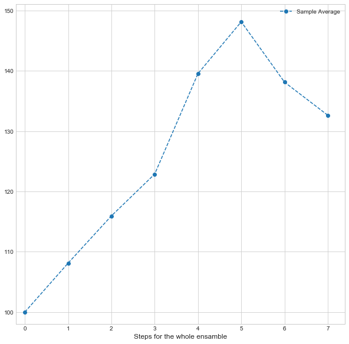

```python
averages = complete_process['Sample Average']
y = averages.to_frame().set_index(np.arange(steps))
ax = y.plot(grid=True,figsize=(10,10), linestyle = '--', marker = 'o');
ax.set_xlabel('Steps for the whole ensamble', fontsize=12);
ax.axis([-0.2,7.4, min(y.values)-min(y.values)/50, max(y.values)+ max(y.values)/50]);
```

**Below we calculate the average of the sample averages.**

```python
averages.mean()
```

```
125.6745926717682
```

Now we do the same thing, but we do 8 simulations, not only one.  
So we have 8 stocastic wealth processes, each consisting of 8 steps

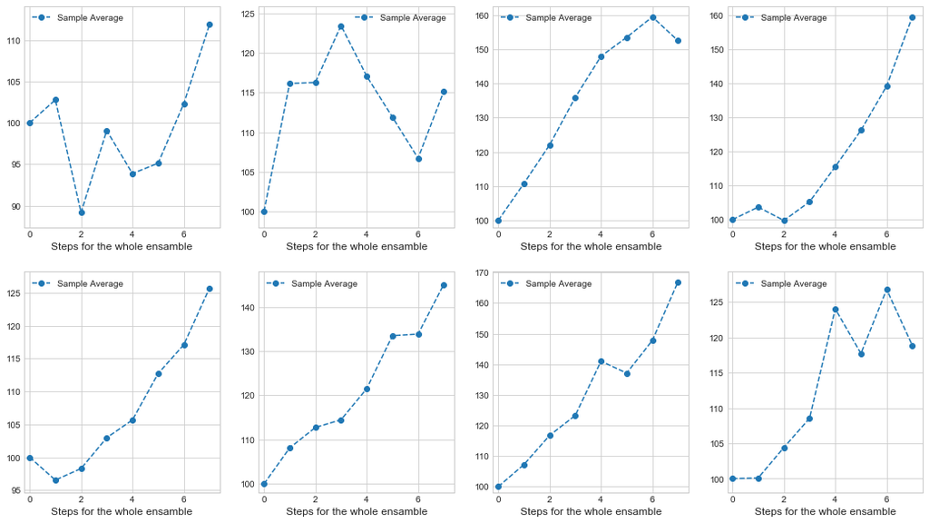

```python
from itertools import product

list_averages = []
fig, axes = plt.subplots(2,4, figsize=(18,10))
t1 = (0,1)
t2 = (0,1,2,3)
generate_x_y = product(t1,t2)
for i in range(8):
    complete_process = ensamble_simulation(starting_process, steps)
    averages = complete_process['Sample Average']
    list_averages.append(averages.mean())
    g,k = next(generate_x_y)
    y = averages.to_frame().set_index(np.arange(steps))
    y.plot(grid=True, ax = axes[g,k], linestyle = '--', marker = 'o');
    axes[g,k].set_xlabel('Steps for the whole ensamble', fontsize=12);
    axes[g,k].axis([-0.2,7.4, min(y.values)-min(y.values)/50, max(y.values)+ max(y.values)/50 ])
```

**Below you can see the averages of the sample averages for each stocastic wealth process.**

```python
averages_value = pd.Series(list_averages) # sample averages of 8 simulation with 8 time steps
averages_value
```

```
0     99.277068
1    113.333344
2    135.234650
3    118.643156
4    107.372753
5    121.149934
6    130.017076
7    112.545082
dtype: float64
```

To understand how this column moves with time, we increase the number of steps of each simulation  
Below we have 8 stocastic processes, and each process consists of 50 steps.

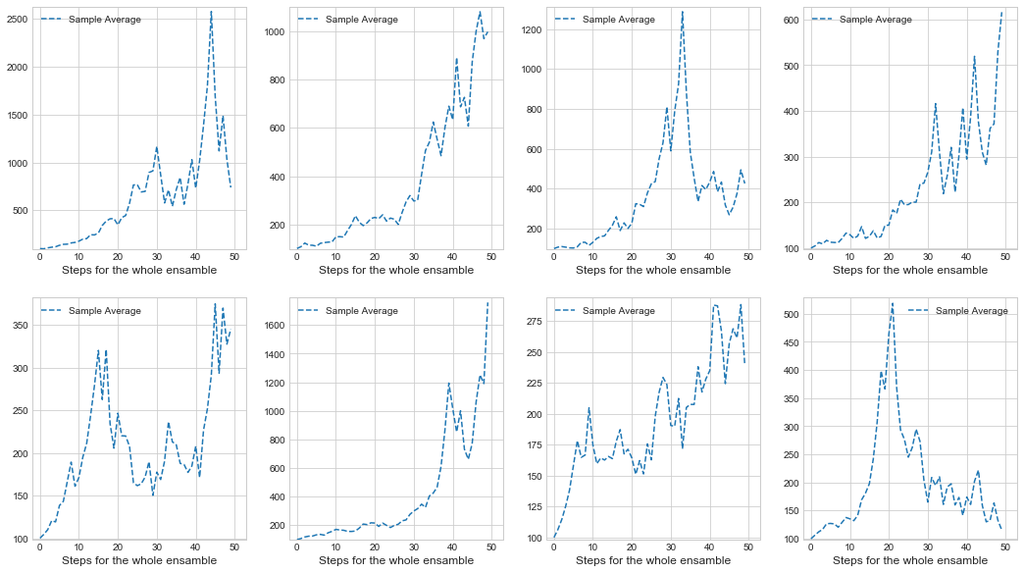

```python
steps = 50
complete_process = ensamble_simulation(starting_process, steps)

list_averages = []
fig, axes = plt.subplots(2,4, figsize=(18,10))
t1 = (0,1)
t2 = (0,1,2,3)
generate_x_y = product(t1,t2)
for i in range(8):
    complete_process = ensamble_simulation(starting_process, steps)
    averages = complete_process['Sample Average']
    list_averages.append(averages.mean())
    g,k = next(generate_x_y)
    y = averages.to_frame().set_index(np.arange(steps))
    y.plot(grid=True, ax = axes[g,k], linestyle = '--');
    axes[g,k].set_xlabel('Steps for the whole ensamble', fontsize=12);
    axes[g,k].axis([-2,53, min(y.values)-min(y.values)/50, max(y.values)+ max(y.values)/50 ])
```

**Let's see the column of the averages value. The expected value of the ensemble wealth has increased.**

```python
averages_value = pd.Series(list_averages) # sample averages of 8 simulations with 50 time steps
averages_value
```

```
0    641.684589
1    378.852719
2    360.285598
3    230.145481
4    209.629599
5    415.774149
6    193.489833
7    201.508858
dtype: float64
```

Ok, now we carry on the steps of each simulation from 50 steps to 350 steps.  
Below you can see the paths of 8 stocastic processes, each consisting of 350 steps.  
What do you notice?

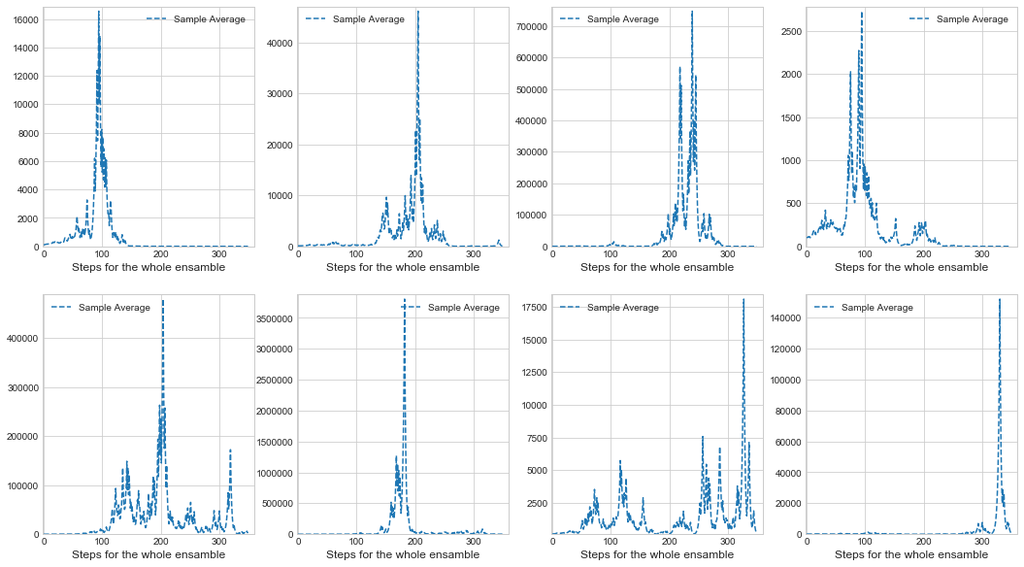

```python
steps = 350
complete_process = ensamble_simulation(starting_process, steps)

list_averages = []
fig, axes = plt.subplots(2,4, figsize=(18,10))
t1 = (0,1)
t2 = (0,1,2,3)
generate_x_y = product(t1,t2)
for i in range(8):
    complete_process = ensamble_simulation(starting_process, steps)
    averages = complete_process['Sample Average']
    list_averages.append(averages.mean())
    g,k = next(generate_x_y)
    y = averages.to_frame().set_index(np.arange(steps))
    y.plot(grid=True, ax = axes[g,k], linestyle = '--');
    axes[g,k].set_xlabel('Steps for the whole ensamble', fontsize=12);
    axes[g,k].axis([-2,360, min(y.values)-min(y.values)/50, max(y.values)+ max(y.values)/50])
```

In the graphs showed above, i notice that all the stocastic process are doomed in the long term  
So, as only every single wealth person is doomed in time, in the same way the ensemble wealth is doomed in time under the multiplicative dynamics of the hypothesis.  
But what about the expectated value of the wealth?  
Below you can see the averages for each stocastic process...

```python
averages_value = pd.Series(list_averages) # sample averages of 8 simulations with 350 time steps
averages_value
```

```
0      758.618391
1     2031.511236
2    36964.693195
3      199.577018
4    32382.300980
5    96017.970895
6     1360.557004
7     2712.400275
dtype: float64
```

```python
averages_value.mean()
```

```
21553.453624254103
```